# linear-models-output

[figure not shown]

## Linear Model Outputs: What Does It All Mean?

*Julia Piaskowski*

*March 10, 2026*

## Linear Model Review

$$Y_i = \beta_0 + \beta_1 X_i + \epsilon_i$$

$Y_i$ = dependent variable (there is only 1)

$X_i$ = independent variable(s) (there may be many)

$B_1$ = how $Y$ changes with $X$

$\epsilon_i$ = model residual, the gap between the predicted value for $Y_i$ and its observed value

## The Residual Is Important

$$\epsilon_i \sim N(0, \sigma)$$

- The residuals are normally distributed with a mean of zero and some standard deviation that we will estimate during the model-fitting process.
- All model residuals are *independent and identically distributed*, “i.i.d.” – they are uncorrelated with each other and drawn from the same distribution (that has exactly one variance)

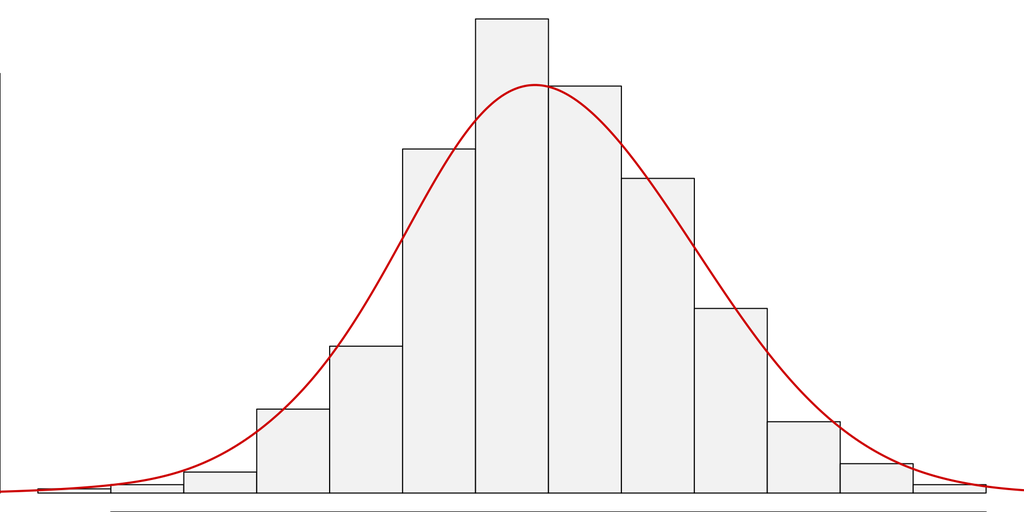

## Some Notes on Estimation

$$\hat{Y} = \beta_0 + \beta_1 X1 + \beta_2 X2 + ...\beta_k Xk$$

$$\hat{Y} = \mathbf{XB}$$

$\hat{Y}$ = predicted/fitted value  
$\beta_0$ = model intercept  
$\beta_1, \beta_2,...$ = model coefficients

## Some Notes on Estimation

#### *Maximum likelihood Estimation (MLE)*

- How most frequentist statistical equations are “solved”
- Iterative approach, find the most probable set of model parameters (coefficients and variance terms) that maximizes a likelihood function
- If a data set is perfectly balanced, maximum likelihood has the same results as ordinary least squares
- REML (restricted maximum likelihood) is a special type of MLE for mixed models.
- ordinary least squares (OLS) is the original method, but it’s less flexible than MLE

# Definitions

## P-value

…a p-value is the probability under a specified statistical model that a statistical summary of the data (e.g., the sample mean difference between two compared groups) would be equal to or more extreme than its observed value.

– [American Statistical Association](https://doi.org/10.1080/00031305.2016.1154108)

## Confidence Interval

[A confidence interval percentage] is the frequency with which other unobserved intervals will contain the true effect….if all the assumptions used to compute the intervals were correct.

– Greenland et al, [2016](https://pmc.ncbi.nlm.nih.gov/articles/PMC4877414/)

The confidence level instead reflects the long-run reliability of the method used to generate the interval….if the same sampling procedure were repeated 100 times from the same population, approximately 95 of the resulting intervals would be expected to contain the true population mean. The frequentist approach sees the true population mean as a fixed unknown constant, while the confidence interval is calculated using data from a random sample.

– [Wikipedia](https://en.wikipedia.org/wiki/Confidence_interval)

# Regression

## Regression Example

Simple linear regression: one continuous independent variable

```r
data(anscombe); head(anscombe, n = 4)
```

```
  x1 x2 x3 x4   y1   y2    y3   y4
1 10 10 10  8 8.04 9.14  7.46 6.58
2  8  8  8  8 6.95 8.14  6.77 5.76
3 13 13 13  8 7.58 8.74 12.74 7.71
4  9  9  9  8 8.81 8.77  7.11 8.84
```

## Regression Example

```r
m1 <- lm(y1 ~ x1, data = anscombe)
plot(anscombe$x1, anscombe$y1, pch = 21, bg = "blue3"); abline(3, 0.5)
```

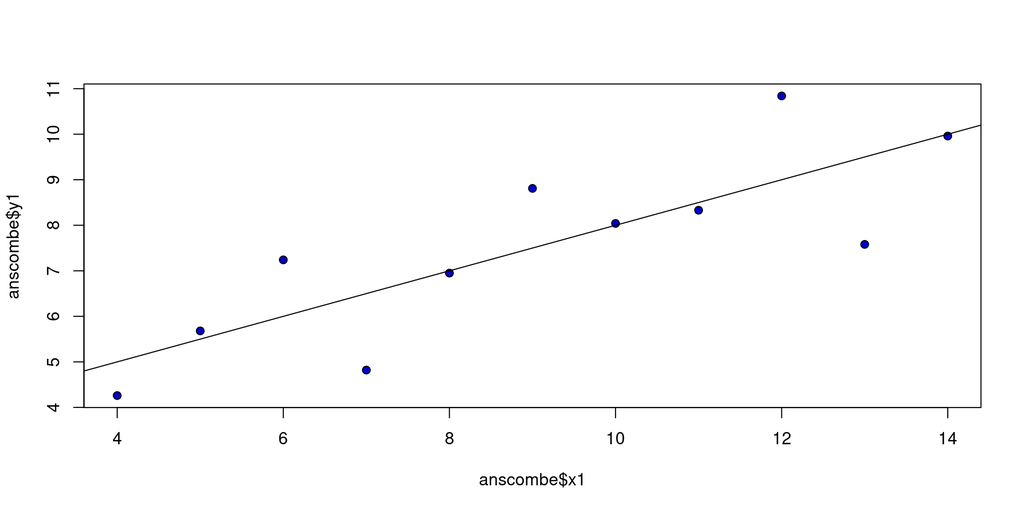

## Regression Example

- `print(m1)` is a pretty printing of some output
- `summary(m1)` is a function with pre-selected and formatted output

```r
(s1 <- summary(m1))
```

```
Call:
lm(formula = y1 ~ x1, data = anscombe)

Residuals:
     Min       1Q   Median       3Q      Max
-1.92127 -0.45577 -0.04136  0.70941  1.83882

Coefficients:
            Estimate Std. Error t value Pr(>|t|)
(Intercept)   3.0001     1.1247   2.667  0.02573 *
x1            0.5001     0.1179   4.241  0.00217 **
---
Signif. codes:  0 '***' 0.001 '**' 0.01 '*' 0.05 '.' 0.1 ' ' 1

Residual standard error: 1.237 on 9 degrees of freedom
Multiple R-squared:  0.6665,    Adjusted R-squared:  0.6295
F-statistic: 17.99 on 1 and 9 DF,  p-value: 0.00217
```

## Regression Output

Model coefficients

```r
s1$coefficients
```

```
             Estimate Std. Error  t value    Pr(>|t|)
(Intercept) 3.0000909  1.1247468 2.667348 0.025734051
x1          0.5000909  0.1179055 4.241455 0.002169629
```

- the “(Intercept)” is $\beta_0$ and “x1” is $\beta_1$
- the Standard error of the estimate is given
- the t value is from the student’s t-distribution
- P-value is evaluating if the estimate is different from zero

## Regression Output

Other valuable output

```r
s1$sigma # standard deviation of the residuals
```

```
[1] 1.236603
```

```r
s1$r.squared # model R^2
```

```
[1] 0.6665425
```

```r
s1$adj.r.squared # adjusted model R^2
```

```
[1] 0.6294916
```

## Regression Output

Other valuable output: F-statistic  
- overall indicator of model fit  
- comparing to a null model: `y ~ 1` (intercept-only model)

```r
s1$fstatistic
```

```
   value    numdf    dendf
17.98994  1.00000  9.00000
```

```r
pf(s1$fstatistic[1], s1$fstatistic[2], s1$fstatistic[3], lower.tail = FALSE)
```

```
      value
0.002169629
```

## Other Regression Output

```r
s1$call # model reminder
s1$term # function data conditining
s1$residuals # raw residuals
s1$df # degrees of freedom
s1$aliased # check that no variables are linearly dependent
s1$fstatistic # model F-test
```

*(I tend not to need these unless doing something very specific)*

## More Regression Output

*From the model object*

```r
coef(m1)
```

```
(Intercept)          x1
  3.0000909   0.5000909
```

```r
residuals(m1)
```

```
          1           2           3           4           5           6
 0.03900000 -0.05081818 -1.92127273  1.30909091 -0.17109091 -0.04136364
          7           8           9          10          11
 1.23936364 -0.74045455  1.83881818 -1.68072727  0.17945455
```

## Possible Regression Output

```r
class(m1)
```

```
[1] "lm"
```

```r
methods(class = "lm")
```

```
 [1] add1           alias          anova          case.names     coerce
 [6] confint        cooks.distance deviance       dfbeta         dfbetas
[11] drop1          dummy.coef     effects        extractAIC     family
[16] formula        fortify        hatvalues      influence      initialize
[21] kappa          labels         logLik         model.frame    model.matrix
[26] nobs           plot           predict        print          proj
[31] qqnorm         qr             residuals      rstandard      rstudent
[36] show           simulate       slotsFromS3    summary        variable.names
[41] vcov
see '?methods' for accessing help and source code
```

These are built-in methods for this class of object, and are dependent on the libraries loaded

## Possible Regression Output

- `confint()` provides confidence interval of parameters
- `extractAIC()` and `logLik()` return fit statistics
- `hatvalues()`, `dfbetas()`, `cooks.distance()`, and `influence()` are model diagnostics tools
- `drop()` and `add1()` drop/add terms sequentially and evaluate model fit statistics (not applicable for simple linear regression)
- `plot()` provides diagnostic plots (= `plot.lm()`)
- `simulate()` simulates data under the estimated model parameters
- `residuals()`, `rstandard()`, `rstudent()` produce raw, Pearson and studentized residuals, respectively
- `predict()` is for predicting a new data set

## Regression Output

Confidence Intervals

```r
confint(m1)
```

```
                2.5 %    97.5 %
(Intercept) 0.4557369 5.5444449
x1          0.2333701 0.7668117
```

```r
confint(m1, level = 0.90)
```

```
                  5 %     95 %
(Intercept) 0.9383030 5.061879
x1          0.2839568 0.716225
```

## Regression Output

Influential data points

```r
influence(m1)
```

```
$hat
         1          2          3          4          5          6          7
0.10000000 0.10000000 0.23636364 0.09090909 0.12727273 0.31818182 0.17272727
         8          9         10         11
0.31818182 0.17272727 0.12727273 0.23636364

$coefficients
     (Intercept)            x1
1   0.0003939394  3.939394e-04
2  -0.0097529844  5.133150e-04
3   0.5946796537 -9.148918e-02
4   0.1309090909 -4.763503e-19
5   0.0142575758 -3.564394e-03
6   0.0193030303 -2.757576e-03
7   0.5039170829 -4.085814e-02
8  -0.5430000000  4.936364e-02
9  -0.3435154845  6.062038e-02
10 -0.4902121212  3.501515e-02
11  0.0982727273 -8.545455e-03

$sigma
       1        2        3        4        5        6        7        8
1.311535 1.311479 1.056460 1.218483 1.310017 1.311496 1.219936 1.272721
       9       10       11
1.099742 1.147055 1.309605

$wt.res
          1           2           3           4           5           6
 0.03900000 -0.05081818 -1.92127273  1.30909091 -0.17109091 -0.04136364
          7           8           9          10          11
 1.23936364 -0.74045455  1.83881818 -1.68072727  0.17945455
```

## Influence Measures

How much single data points influence model parmaters

- [DF fits:](https://en.wikipedia.org/wiki/DFFITS) change in fits
- [DF betas:](https://en.wikipedia.org/wiki/Influential_observation) change in parameters
- [PRESS statistic:](https://en.wikipedia.org/wiki/PRESS_statistic) leave-one-out predicted sum of squares
- [hat values](https://en.wikipedia.org/wiki/Projection_matrix), [Cook’s D](https://en.wikipedia.org/wiki/Cook%27s_distance)(istance): X values that are extreme

(DF refers to difference)

## $R^2$ versus $r$

- $R^2$ coefficient of determination

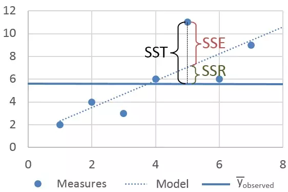

[Image Source](https://www.sciencedirect.com/science/article/abs/pii/S0001457517303962)

## $R^2$ versus $r$

$R^2$ coefficient of determination
$$R^2 = 1 - \frac {SS_{error}}{SS_{reg} + SS_{errror}} = \frac {SS_{reg}}{SS_{reg} + SS_{errror}}$$

$$0 \leq R^2 \leq 1$$

- For measuring the strength of a regression
- $R^2$ exists, $R$ does not

## $R^2$ versus $r$

$r$ coefficient of correlation:

$$r_{xy} = \frac{s_{xy}}{s_x s_y}$$

$$-1 \leq r \leq 1$$

- For understanding pairwise relationships
- $r^2$ = $R^2$ only in the case of simple linear regression

## Multiple Linear Regression

```r
data(mtcars)
head(mtcars, n = 4)
```

```
                mpg cyl disp  hp drat    wt  qsec vs am gear carb
Mazda RX4      21.0   6  160 110 3.90 2.620 16.46  0  1    4    4
Mazda RX4 Wag  21.0   6  160 110 3.90 2.875 17.02  0  1    4    4
Datsun 710     22.8   4  108  93 3.85 2.320 18.61  1  1    4    1
Hornet 4 Drive 21.4   6  258 110 3.08 3.215 19.44  1  0    3    1
```

```r
m2 <- lm(mpg ~ disp + hp + drat, data = mtcars)
```

## Multiple Linear Regression

```r
summary(m2)
```

```
Call:
lm(formula = mpg ~ disp + hp + drat, data = mtcars)

Residuals:
    Min      1Q  Median      3Q     Max
-5.1225 -1.8454 -0.4456  1.1342  6.4958

Coefficients:
             Estimate Std. Error t value Pr(>|t|)
(Intercept) 19.344293   6.370882   3.036  0.00513 **
disp        -0.019232   0.009371  -2.052  0.04960 *
hp          -0.031229   0.013345  -2.340  0.02663 *
drat         2.714975   1.487366   1.825  0.07863 .
---
Signif. codes:  0 '***' 0.001 '**' 0.01 '*' 0.05 '.' 0.1 ' ' 1

Residual standard error: 3.008 on 28 degrees of freedom
Multiple R-squared:  0.775, Adjusted R-squared:  0.7509
F-statistic: 32.15 on 3 and 28 DF,  p-value: 3.28e-09
```

## Multiple Linear Regression

```r
drop1(m2)
```

```
Single term deletions

Model:
mpg ~ disp + hp + drat
       Df Sum of Sq    RSS    AIC
<none>              253.35 74.209
disp    1    38.107 291.45 76.693
hp      1    49.550 302.90 77.925
drat    1    30.148 283.49 75.806
```

# ANOVA

*(Regression with categorical variables)*

## ANOVA

```r
data(npk)
head(npk, n = 10)
```

```
   block N P K yield
1      1 0 1 1  49.5
2      1 1 1 0  62.8
3      1 0 0 0  46.8
4      1 1 0 1  57.0
5      2 1 0 0  59.8
6      2 1 1 1  58.5
7      2 0 0 1  55.5
8      2 0 1 0  56.0
9      3 0 1 0  62.8
10     3 1 1 1  55.8
```

## ANOVA

*(ignoring block)*

N: 2 levels, 0 and 1  
P: 2 levels, 0 and 1  
K: 2 levels, 0 and 1

$$Y_{ijk+} = \beta_0 + \beta_1N +\beta_2P + \beta_3K$$

## ANOVA

*(with block)*

**6 levels of block**  
block 1: 0 only  
block 2: 0 and 1  
block 3: 0 and 1  
….(blocks 4, 5, 6): 0 and 1

*(set one level as level zero or reference level)*

| ID | block1 | block 2 | block 3 | block 4 | block 5 | block 6 |
| --- | --- | --- | --- | --- | --- | --- |
| A | 0 | 1 | 0 | 0 | 0 | 0 |
| B | 0 | 0 | 1 | 0 | 0 | 0 |
| C | 0 | 0 | 0 | 1 | 0 | 0 |
| D | 0 | 0 | 0 | 0 | 1 | 0 |
| E | 0 | 0 | 0 | 0 | 0 | 1 |

$$Y_{npk} = \beta_0 +...+ \beta_4 Bl2 + \beta_5 Bl3 + \beta_6 Bl4 + \beta_7 Bl5 + \beta_8 Bl6$$

## ANOVA

```r
m3 <- lm(yield ~N + P + K + block, data = npk)
summary(m3)
```

```
Call:
lm(formula = yield ~ N + P + K + block, data = npk)

Residuals:
    Min      1Q  Median      3Q     Max
-7.0000 -1.7083 -0.0833  2.2458  6.4833

Coefficients:
            Estimate Std. Error t value Pr(>|t|)
(Intercept)   53.800      2.450  21.955 8.13e-13 ***
N1             5.617      1.634   3.438  0.00366 **
P1            -1.183      1.634  -0.724  0.47999
K1            -3.983      1.634  -2.438  0.02767 *
block2         3.425      2.830   1.210  0.24483
block3         6.750      2.830   2.386  0.03068 *
block4        -3.900      2.830  -1.378  0.18831
block5        -3.500      2.830  -1.237  0.23512
block6         2.325      2.830   0.822  0.42412
---
Signif. codes:  0 '***' 0.001 '**' 0.01 '*' 0.05 '.' 0.1 ' ' 1

Residual standard error: 4.002 on 15 degrees of freedom
Multiple R-squared:  0.7259,    Adjusted R-squared:  0.5798
F-statistic: 4.966 on 8 and 15 DF,  p-value: 0.003761
```

## ANOVA

Type 1 sums of squares

```r
anova(m3)
```

```
Analysis of Variance Table

Response: yield
          Df Sum Sq Mean Sq F value  Pr(>F)
N          1 189.28 189.282 11.8210 0.00366 **
P          1   8.40   8.402  0.5247 0.47999
K          1  95.20  95.202  5.9455 0.02767 *
block      5 343.29  68.659  4.2879 0.01272 *
Residuals 15 240.19  16.012
---
Signif. codes:  0 '***' 0.001 '**' 0.01 '*' 0.05 '.' 0.1 ' ' 1
```

## ANOVA

Type 3 sums of squares

```r
drop1(m3, test = "F")
```

```
Single term deletions

Model:
yield ~ N + P + K + block
       Df Sum of Sq    RSS    AIC F value  Pr(>F)
<none>              240.19 73.281
N       1    189.28 429.47 85.228 11.8210 0.00366 **
P       1      8.40 248.59 72.106  0.5247 0.47999
K       1     95.20 335.39 79.294  5.9455 0.02767 *
block   5    343.29 583.48 84.583  4.2879 0.01272 *
---
Signif. codes:  0 '***' 0.001 '**' 0.01 '*' 0.05 '.' 0.1 ' ' 1
```

## Sums of Squares

**Type 1:** depends on order of independent variables  
**Type 3:** best for factorials  
**Type 2:** use if you are sure there are no interactions

**These only matter if the data are unbalanced**

[Decent explanation](https://www.r-bloggers.com/2011/03/anova-%E2%80%93-type-iiiiii-ss-explained/)

# Mixed Models

## Mixed Models

```r
library(lme4); library(lmerTest)
m4 <- lmer(yield ~N + P + K + (1|block), data = npk)
m4
```

```
Linear mixed model fit by REML ['lmerModLmerTest']
Formula: yield ~ N + P + K + (1 | block)
   Data: npk
REML criterion at convergence: 128.057
Random effects:
 Groups   Name        Std.Dev.
 block    (Intercept) 3.628
 Residual             4.002
Number of obs: 24, groups:  block, 6
Fixed Effects:
(Intercept)           N1           P1           K1
     54.650        5.617       -1.183       -3.983
```

## Mixed Models

```r
fixef(m4) # fixed effects
```

```
(Intercept)          N1          P1          K1
  54.650000    5.616667   -1.183333   -3.983333
```

```r
ranef(m4) # random effects
```

```
$block
  (Intercept)
1   -0.651767
2    1.974470
3    4.524029
4   -3.642227
5   -3.335513
6    1.131007

with conditional variances for "block"
```

## Mixed Models

```r
sigma(m4)
```

```
[1] 4.001541
```

```r
print(VarCorr(m4), comp = c("Variance", "Std.Dev"))
```

```
 Groups   Name        Variance Std.Dev.
 block    (Intercept) 13.162   3.6279
 Residual             16.012   4.0015
```

```r
confint(m4)
```

```
                2.5 %     97.5 %
.sig01       1.201048  7.3624368
.sigma       2.720672  5.2696730
(Intercept) 50.396060 58.9039408
N1           2.530694  8.7026395
P1          -4.269306  1.9026395
K1          -7.069306 -0.8973605
```

## Mixed Models

A large number of functions are providing model conditions, not something estimated.

```r
family(m4) # distribution (Gaussian, etc)
na.action(m4) # how missing data were handled
isREML(m4) # yes/no was REML used?
formula(m4) # formula used
getData(m4) # return data set
nobs(m4) # data set size
ngrps(m4) # number of random groups
```

## Mixed Models

*So many methods*

```r
methods(class = "merMod")
```

```
 [1] anova          as.function    coef           confint        cooks.distance
 [6] deviance       df.residual    drop1          extractAIC     family
[11] fitted         fixef          formula        fortify        getData
[16] getL           getME          hatvalues      influence      isGLMM
[21] isLMM          isNLMM         isREML         isSingular     logLik
[26] model.frame    model.matrix   na.action      ngrps          nobs
[31] plot           predict        print          profile        ranef
[36] refit          refitML        rePCA          residuals      rstudent
[41] show           sigma          simulate       summary        terms
[46] update         VarCorr        vcov           weights
see '?methods' for accessing help and source code
```

```r
methods(class = "lmerModLmerTest")
```

```
 [1] anova       coerce      coerce<-    contest     contest1D   contestMD
 [7] difflsmeans drop1       getL        isSingular  ls_means    lsmeansLT
[13] show        step        summary     update
see '?methods' for accessing help and source code
```

## Mixed Models

- Test random effects with a log likihood ratio test

```r
ranova(m4)
```

```
ANOVA-like table for random-effects: Single term deletions

Model:
yield ~ N + P + K + (1 | block)
            npar  logLik    AIC    LRT Df Pr(>Chisq)
<none>         6 -64.029 140.06
(1 | block)    5 -66.388 142.78 4.7194  1    0.02982 *
---
Signif. codes:  0 '***' 0.001 '**' 0.01 '*' 0.05 '.' 0.1 ' ' 1
```

## Final Thoughts

- $R^2$, log likelihood, and AIC/BIC are ways to evaluate model fit
- the coefficient for regression can be directly interpreted; ANOVA coefficients are more complex
- Use type 3 sums of squares if you’re unclear
- linear modelling objects have a large amount of output, use `methods()` to explore this content
- ANOVA is a special case of regression; they are both linear models

## Additional Resources

- [An R Companion to Applied Regression](https://www.john-fox.ca/Companion/) (2019), $3^{rd}$ Ed., by John Fox and Sanford Weisberg.
- Learn more about [functions for detecting influential data](https://web.mit.edu/~r/current/arch/i386_linux26/lib/R/library/stats/html/influence.measures.html)
- [SAS User Guide to Linear Models](https://documentation.sas.com/doc/en/statug/latest/statug_intromix_sect009.htm)
- [Linear Mixed Model Guide:](https://idahoagstats.github.io/mixed-models-in-R/) details on implementation of linear mixed models in R